# The ‘Epidemiological Report’ Package

European Centre for Disease Prevention and Control (ECDC)

## Description

The EpiReport package allows the user to draft an epidemiological report similar to the ECDC Annual Epidemiological Report (AER) (see https://www.ecdc.europa.eu/en/publications-data/monitoring/all-annual-epidemiological-reports) in Microsoft Word format for a given disease.

Through standalone functions, the package is specifically designed to generate each disease-specific output presented in these reports, using ECDC Atlas export data.

Package details below:

| Package | Description |
| --- | --- |
| Version | 1.0.3 |
| Published | 2025-04-18 |
| Authors | Lore Merdrignac l.merdrignac@epiconcept.fr, Author of the package and original code Tommi Karki tommi.karki@ecdc.europa.eu, Esther Kissling e.kissling@epiconcept.fr, Joana Gomes Dias joana.gomes.dias@… |
| Maintainer |  |
| License | EUPL |
| Link to the ECDC AER reports | https://www.ecdc.europa.eu/en/publications-data/monitoring/all-annual-epidemiological-reports |

## Background

ECDC’s annual epidemiological report is available as a series of individual epidemiological disease reports. Reports are published on the ECDC website https://www.ecdc.europa.eu/en/publications-data/monitoring/all-annual-epidemiological-reports as they become available.

The year given in the title of the report (i.e. ‘Annual epidemiological report for 2016’) refers to the year the data were collected. Reports are usually available for publication one year after data collection is complete.

All reports are based on data collected through The European Surveillance System (TESSy)[^1] and exported from the ECDC Atlas. Countries participating in disease surveillance submit their data electronically.

The communicable diseases and related health issues covered by the reports are under European Union and European Economic Area disease surveillance[^2] [^3] [^4] [^5].

ECDC’s annual surveillance reports provide a wealth of epidemiological data to support decision-making at the national level. They are mainly intended for public health professionals and policymakers involved in disease prevention and control programmes.

## 1. Datasets to be used in the Epidemiological Report package

### 1.1. Disease dataset specification

Two types of datasets can be used:

- The default dataset included in the `EpiReport` package which includes Salmonellosis data for 2012-2016: `EpiReport::SALM2016`;
- Any dataset specified as described below.

Description of each variable required in the disease dataset (naming and format):

**Tab.1 Example of Salmonellosis data 2012-2016**

| HealthTopicCode | MeasurePopulation | MeasureCode | TimeUnit | TimeCode | GeoCode | XLabel | YLabel | ZValue | YValue | N |
| --- | --- | --- | --- | --- | --- | --- | --- | --- | --- | --- |
| SALM | Confirmed cases | CONFIRMED.AGE.COUNT | M | 2012-06 | DK | 15-24 | NA | NA | 1.200000e+01 | 112 |
| SALM | Confirmed cases | CONFIRMED.COUNT | M | 2013-05 | EU28 | NA | NA | NA | 6.673000e+03 | 6673 |
| SALM | Confirmed cases | CONFIRMED.AGE.RATE | M | 2015-02 | EE | 45-64 | NA | NA | 2.903204e-01 | 1 |
| SALM | Confirmed cases | CONFIRMED.GENDER.COUNT | Y | 2015 | DE | Female | NA | NA | 6.690000e+03 | 13667 |
| SALM | Confirmed cases | CONFIRMED.AGE.RATE | M | 2014-09 | DK | 65+ | NA | NA | 7.791697e-01 | 104 |
| SALM | Confirmed cases | CONFIRMED.AGE_GENDER.RATE | Y | 2015 | NL | 65+ | Male | 8.826524 | 1.000000e+00 | 974 |
| SALM | Confirmed cases | CONFIRMED.GENDER.COUNT | M | 2016-06 | LV | Male | NA | NA | 1.000000e+01 | 18 |
| SALM | Confirmed cases | CONFIRMED.GENDER.COUNT | M | 2016-04 | EE | Female | NA | NA | 4.300000e+01 | 87 |
| SALM | Confirmed cases | CONFIRMED.AGE.COUNT | M | 2012-01 | SI | 25-44 | NA | NA | 3.000000e+00 | 15 |
| SALM | Confirmed cases | CONFIRMED.AGE.COUNT | Y | 2013 | EU_EEA31 | 65+ | NA | NA | 1.174200e+04 | 81081 |

### 1.2. Report parameters dataset specification

The internal dataset `EpiReport::AERparams` describes the parameters to be used for each output of each disease report.

If the user wishes to set different parameters for one of the 53 covered health topics, or if the user wishes to analyse an additional disease not covered by the default parameter table, it is possible to use an external dataset as long as it is specified as described below and in the help page `?EpiReport::AERparams`. All functions of the `EpiReport` package can then be fed with this specific parameter table.

List of the main parameters included:

- `HealthTopic`: Character string, disease code that should match with the health topic code from the disease-specific dataset (see Tab.1)
- `MeasurePopulation`: Character string, population to present in the report: either `ALL` cases or `CONFIRMED` cases only.
- `TableUse`: Character string, specifying whether to include the table in the epidemiological report and which table to include:
  - `NO`: No table included
  - `COUNT`: Table presenting the **number of cases** by Member State by year
  - `RATE`: Table presenting the **rates** of cases by Member State by year
  - `ASR`: Table presenting the **age-standardised** rates of cases by Member State by year
- `AgeGenderUse`: Character string, specifying whether to include the age and gender bar graph in the epidemiological report and which type of graph to include:
  - `NO`: No graph included
  - `AG-COUNT`: Bar graph presenting the **number of cases** by age and gender
  - `AG-RATE`: Bar graph presenting the **rates** of cases by age and gender
  - `AG-PROP`: Bar graph presenting the **proportion** of cases by age and gender
  - `A-RATE`: Bar graph presenting the **rates** of cases by age
- `TSTrendGraphUse`: Yes/No, specifying whether to include a line graph describing the trend of the disease over the time.
- `TSSeasonalityGraphUse`: Yes/No, specifying whether to include a line graph describing the seasonality of the disease.
- `MapNumbersUse`: Yes/No, specifying whether to include the map presenting the **number of cases** by Member State.
- `MapRatesUse`: Yes/No, specifying whether to include the map presenting the **rates** of cases by Member State.
- `MapASRUse`: Yes/No, specifying whether to include the map presenting the **age-standardised rates** of cases by Member State.

**Tab.2 Example of the main columns of the parameter dataset**

| HealthTopic | MeasurePopulation | TableUse | AgeGenderUse | TSTrendGraphUse | TSSeasonalityGraphUse | MapNumbersUse | MapRatesUse | MapASRUse |
| --- | --- | --- | --- | --- | --- | --- | --- | --- |
| HEPB | CONFIRMED | STAGE | AG-RATE | N | N | N | N | N |
| RIFT | ALL | NO | NO | N | N | N | N | N |
| POLI | ALL | NO | NO | N | N | N | N | N |
| TBE | CONFIRMED | ASR | AG-RATE | Y | Y | N | Y | N |
| LGV | CONFIRMED | COUNT | NO | N | N | N | N | N |

### 1.3. Member States correspondence table dataset

The internal dataset `EpiReport::MSCode` provides the correspondence table of the geographical code `GeoCode` used in the disease dataset, and the geographical label `Country` to use throughout the report. Additional information on the EU/EEA affiliation is also available in column `EUEEA`.

**Tab.3 Example of geographical codes and associated labels**

| Country | GeoCode | EUEEA | TheCountry |
| --- | --- | --- | --- |
| France | FR | EU | France |
| Hungary | HU | EU | Hungary |
| Finland | FI | EU | Finland |
| Poland | PL | EU | Poland |
| Italy | IT | EU | Italy |

## 2. How to generate the Epidemiological Report in Microsoft Word format

To generate a similar report to the Annual Epidemiological Report, we can use the default dataset included in the `EpiReport` package presenting Salmonellosis data 2012-2016.

```r
getAER()
```

Please specify the full path to the output folder if necessary:

```r
output <- "C:/EpiReport/doc/"
getAER(outputPath = output)
```

### 2.1. External disease dataset

To generate the report using an external dataset, please use the syntax below.

In the following example, Pertussis 2016 TESSy data (in csv format, in the `/data` folder) is used to produce the corresponding report.

Pertussis PNG maps have previously been created and stored in a specific folder `/maps`.

```r
# --- Importing the dataset
PERT2016 <- read.table("data/PERT2016.csv",
                       sep = ",",
                       header = TRUE,
                       stringsAsFactors = FALSE)

# --- Specifying the folder containing pertussis maps
pathMap <- paste(getwd(), "/maps", sep = "")


# --- (optional) Setting the local language in English for month label
Sys.setlocale("LC_TIME", "C")
```

```
#> [1] "C"
```

```r
# --- Producing the report
EpiReport::getAER(disease = "PERT",
       year = 2016,
       x = PERT2016,
       pathPNG = pathMap)
```

Please note that the font `Tahoma` is used in the plot axis and legend. It is advised to import this font using the `extrafont` package and the command `font_import` and `loadfonts`.

However, if the users prefer the use of the default `Arial` in plots, it is optional. In that case, warnings will appear in the console for each plot.

### 2.2. Word template

By default, an empty ECDC template (Microsoft Word) is used to produce the report. In order to modify this template, please first download the default template using the function `getTemplate()`.

You can store this Microsoft Word template in a specific folder `/template`.

```r
getTemplate(output_path = "C:/EpiReport/template")
```

Then, apply the modifications required, save it and use it as a new Microsoft Word template when producing the epidemiological report as described below.

```r
getAER(template = "C:/EpiReport/template/New_AER_Template.docx",
       outputPath = "C:/EpiReport/doc/")
```

Please make sure that the Microsoft Word bookmarks are preserved throughout the modifications to the template. The bookmarks specify the location where to include each output.

### 2.3. Word bookmarks

Each epidemiological output will be included in the Word template in the corresponding report chapter. The `EpiReport` package relies on Microsoft Word bookmarks to specify the exact location where to include each output.

The list of bookmarks recognised by the `EpiReport` package are:

- YEAR
- DISEASE
- DATEPUBLICATLAS
- TABLE1_CAPTION
- TABLE1
- MAP_NB_CAPTION
- MAP_NB
- MAP_RATE_CAPTION
- MAP_RATE
- MAP_ASR_CAPTION
- MAP_ASR
- TS_TREND_CAPTION
- TS_TREND
- TS_TREND_COUNTRIES
- TS_SEASON_CAPTION
- TS_SEASON
- TS_SEASON_COUNTRIES
- BARGPH_AGEGENDER_CAPTION
- BARGPH_AGEGENDER
- BARGPH_AGE_CAPTION
- BARGPH_AGE

## 3. How to generate each epidemiological outputs independently

The `EpiReport` package allows the user to generate each epidemiological output independently of the Microsoft Word report.

The ECDC annual epidemiological Report includes five types of outputs:

- **Table**: Distribution of cases by Member State over the last five years with:
  - the number of cases only;
  - the number of cases and the corresponding rate per 100 000 population or
  - the number of cases, the rate and the age-standardised rate per 100 000 population.
- **Seasonality plot**: Distribution of cases at EU/EEA level, by month, over the past five years.
- **Trend plot**: Trend and number of cases at EU/EEA level, by month, over the past five years.
- **Map**: Distribution of cases by Member State presenting either:
  - the number of cases;
  - the rates per 100 000 population;
  - the age-standardised rates per 100 000 population.
- **Age and gender bar graph**: Distribution of cases at EU/EEA level:
  - by age and gender and using:
    - the number of cases
    - the rate
    - the proportion of cases
  - by age only and using the rate.

### 3.1. Table: distribution of cases by Member State

The function `getTableByMS()` generates a `flextable` object (see package `flextable`) presenting the number of cases by Member State over the last five years.

```r
EpiReport::getTableByMS()
```

| Country | 2015 Number | 2015 Rate | 2016 Number | 2016 Rate | 2017 Number | 2017 Rate | 2018 Number | 2018 Rate | 2019 Number | 2019 Rate | 2019 ASR |
| --- | --- | --- | --- | --- | --- | --- | --- | --- | --- | --- | --- |
| Austria | 103 | 1.2 | 116 | 1.3 | 85 | 1.0 | 85 | 1.0 | 142 | 1.6 | 1.7 |
| Belgium | 108 | 1.0 | 114 | 1.0 | 77 | 0.7 | 101 | 0.9 | 202 | 1.8 | 1.9 |
| Bulgaria | . | . | . | . | . | . | . | . | . | . | . |
| Croatia | - | - | 2 | 0.0 | 0 | 0.0 | 2 | 0.0 | 4 | 0.1 | 0.1 |
| Cyprus | . | . | . | . | . | . | . | . | . | . | . |
| Czechia | 0 | 0.0 | 0 | 0.0 | 0 | 0.0 | 0 | 0.0 | 0 | 0.0 | 0.0 |
| Denmark | . | . | . | . | . | . | . | . | . | . | . |
| Estonia | 12 | 0.9 | 9 | 0.7 | 8 | 0.6 | 6 | 0.5 | 6 | 0.5 | 0.5 |
| Finland | 54 | 1.0 | 66 | 1.2 | 25 | 0.5 | 56 | 1.0 | 81 | 1.5 | 1.6 |
| France | 285 | 0.4 | 373 | 0.6 | 266 | 0.4 | 331 | 0.5 | 904 | 1.3 | 1.4 |
| Germany | 722 | 0.9 | 958 | 1.2 | 635 | 0.8 | 614 | 0.7 | 1175 | 1.4 | 1.5 |
| Greece | 2 | 0.0 | 2 | 0.0 | 1 | 0.0 | 2 | 0.0 | 10 | 0.1 | 0.1 |
| Hungary | 12 | 0.1 | 24 | 0.2 | 17 | 0.2 | 14 | 0.1 | 44 | 0.5 | 0.5 |
| Iceland | 0 | 0.0 | 0 | 0.0 | 1 | 0.3 | 1 | 0.3 | 4 | 1.1 | 1.1 |
| Ireland | 8 | 0.2 | 18 | 0.4 | 10 | 0.2 | 17 | 0.4 | 18 | 0.4 | 0.4 |
| Italy | 103 | 0.2 | 106 | 0.2 | 95 | 0.2 | 108 | 0.2 | 231 | 0.4 | 0.4 |
| Latvia | 4 | 0.2 | 9 | 0.5 | 13 | 0.7 | 12 | 0.6 | 11 | 0.6 | 0.6 |
| Liechtenstein | . | . | . | . | . | . | . | . | . | . | . |
| Lithuania | 9 | 0.3 | 4 | 0.1 | 4 | 0.1 | 8 | 0.3 | 9 | 0.3 | 0.4 |
| Luxembourg | 0 | 0.0 | 1 | 0.2 | 0 | 0.0 | 1 | 0.2 | 1 | 0.2 | 0.2 |
| Malta | 1 | 0.2 | 1 | 0.2 | 3 | 0.7 | 1 | 0.2 | 2 | 0.4 | 0.4 |
| Netherlands | 18 | - | 6 | - | 0 | - | 0 | - | 0 | - | - |
| Norway | 98 | 1.9 | 64 | 1.2 | 35 | 0.7 | 49 | 0.9 | 102 | 1.9 | 2.0 |
| Poland | 12 | 0.0 | 41 | 0.1 | 29 | 0.1 | 30 | 0.1 | 55 | 0.1 | 0.1 |
| Portugal | 14 | 0.1 | 13 | 0.1 | 11 | 0.1 | 14 | 0.1 | 30 | 0.3 | 0.3 |
| Romania | 7 | 0.0 | 8 | 0.0 | 7 | 0.0 | 4 | 0.0 | 15 | 0.1 | 0.1 |
| Slovakia | 2 | 0.0 | 4 | 0.1 | 2 | 0.0 | 7 | 0.1 | 6 | 0.1 | 0.1 |
| Slovenia | 3 | 0.1 | 6 | 0.3 | 5 | 0.2 | 8 | 0.4 | 21 | 1.0 | 1.1 |
| Spain | 168 | 0.4 | 261 | 0.6 | 128 | 0.3 | 205 | 0.4 | 228 | 0.5 | 0.5 |
| Sweden | 159 | 1.6 | 225 | 2.3 | 106 | 1.1 | 106 | 1.0 | 235 | 2.3 | 2.4 |
| United Kingdom | 423 | 0.7 | 468 | 0.7 | 465 | 0.7 | 432 | 0.7 | 827 | 1.2 | 1.3 |
| EU-EEA | 2327 | 0.5 | 2899 | 0.6 | 2028 | 0.4 | 2214 | 0.5 | 4363 | 0.9 | 0.9 |

This table can be drafted using external data, and specifying the disease code and the year to use as reference in the report.

In the example below, we use Zika virus data. According to the report parameters, the table for this disease should present the number of reported cases over the last five years and by Member State.

```r
ZIKV2016 <- read.table("data/ZIKV2016.csv",
                       sep = ",",
                       header = TRUE,
                       stringsAsFactors = FALSE)
EpiReport::getTableByMS(x = ZIKV2016,
             disease = "ZIKV",
             year = 2016)
```

| Country | 2012 Number | 2013 Number | 2014 Number | 2015 Number | 2016 Number |
| --- | --- | --- | --- | --- | --- |
| Austria | - | - | - | 1 | 41 |
| Belgium | - | - | - | 1 | 120 |
| Bulgaria | . | . | . | . | . |
| Croatia | . | . | . | . | . |
| Cyprus | . | . | . | . | . |
| Czechia | - | - | - | - | 13 |
| Denmark | - | - | - | - | 8 |
| Estonia | - | - | - | - | 0 |
| Finland | - | - | - | 1 | 6 |
| France | - | - | - | - | 1141 |
| Germany | . | . | . | . | . |
| Greece | - | - | - | - | 4 |
| Hungary | - | - | - | - | 2 |
| Iceland | . | . | . | . | . |
| Ireland | - | - | - | 1 | 15 |
| Italy | - | - | - | - | 101 |
| Latvia | 0 | 0 | 0 | 0 | 0 |
| Liechtenstein | . | . | . | . | . |
| Lithuania | . | . | . | . | . |
| Luxembourg | - | - | - | - | 2 |
| Malta | - | - | - | - | 2 |
| Netherlands | - | - | - | 11 | 98 |
| Norway | - | - | - | - | 8 |
| Poland | . | . | . | . | . |
| Portugal | - | - | - | - | 18 |
| Romania | - | - | - | - | 3 |
| Slovakia | - | - | - | - | 3 |
| Slovenia | - | - | - | - | 7 |
| Spain | - | - | - | 10 | 301 |
| Sweden | - | - | - | 1 | 34 |
| United Kingdom | - | - | - | 3 | 194 |
| EU-EEA | 0 | 0 | 0 | 29 | 2121 |

*Table. Distribution of Zika virus infection cases, EU/EEA, 2012-2016*

### 3.2. Seasonality plot: distribution of cases by month

The function `getSeason()` generates a ggplot (see package `ggplot2`) presenting the distribution of cases at EU/EEA level, by month, over the past five years.

The plot includes:

- The number of cases by month in the reference year (green solid line)
- The mean number of cases by month in the four previous years (grey dashed line)
- The minimum number of cases by month in the four previous years (grey area)
- The maximum number of cases by month in the four previous years (grey area)

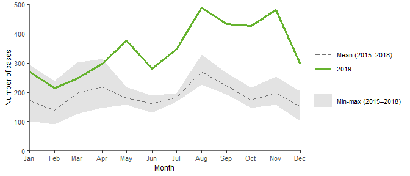

```r
# --- Salmonellosis 2016 plot
EpiReport::getSeason()
```

The plot can also be drafted using external data, and specifying the disease dataset, the disease code and the year to use as reference in the report.

In the example below, we use Pertussis 2012-2016 data.

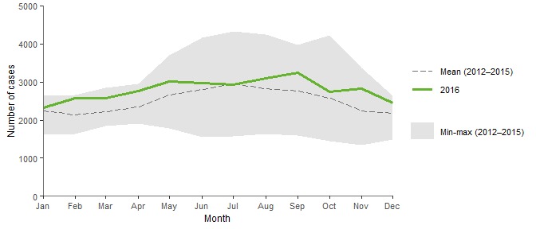

```r
# --- Pertussis 2016 plot
EpiReport::getSeason(x = PERT2016,
                     disease = "PERT",
                     year = 2016)
```

*Figure. Distribution of pertussis cases by month, EU/EEA, 2016 and 2012-2015*

### 3.3. Trend plot: trend and number of cases by month

The function `getTrend()` generates a ggplot (see package `ggplot2`) presenting the trend and the number of cases at EU/EEA level, by month, over the past five years.

The plot includes:

- The number of cases by month over the 5-year period (grey solid line)
- The 12-month moving average of the number of cases by month (green solid line)

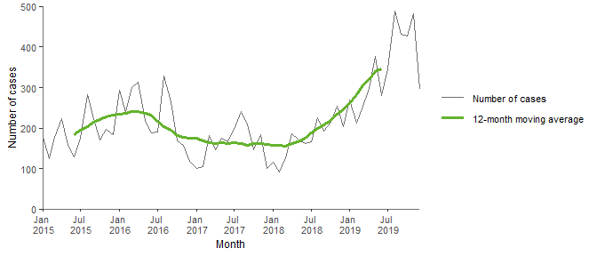

```r
# --- Salmonellosis 2016 plot
EpiReport::getTrend()
```

The plot can also be drafted using external data, and specifying the disease dataset, the disease code and the year to use as reference in the report.

In the example below, we use again Pertussis 2012-2016 data.

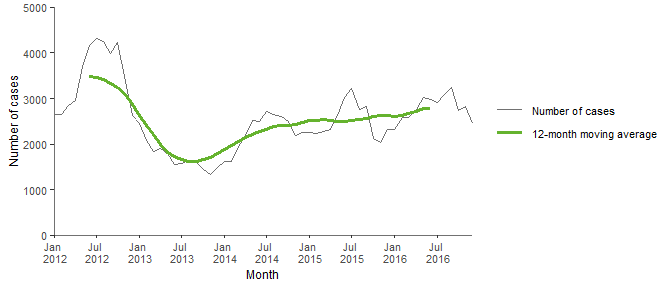

```r
# --- Pertussis 2016 plot
EpiReport::getTrend(x = PERT2016,
                    disease = "PERT",
                    year = 2016)
```

*Figure. Trend and number of pertussis cases, EU/EEA by month, 2012-2016*

### 3.4. Maps: distribution of cases by Member State

The function `getMap()` provides with a preview of the PNG map associated with the disease.

[figure not shown]

```r
# --- Salmonellosis 2016 map
EpiReport::getMap()
```

The map can also be included using external PNG files, and specifying the disease code and the year to use as reference in the report. The corresponding syntax is described below (pertussis map not available).

```r
# --- Pertussis 2016 map
EpiReport::getMap(disease = "PERT",
                  year = 2016,
                  pathPNG = "C:/EpiReport/maps/")
```

### 3.5. Age and gender bar graph

The function `getAgeGender()` generates a ggplot (see package `ggplot2`) presenting in a bar graph the distribution of cases at EU/EEA level by age and gender.

The bar graph uses either:

- The number of cases,
- The rate per 100 000 cases,
- The proportion of cases.

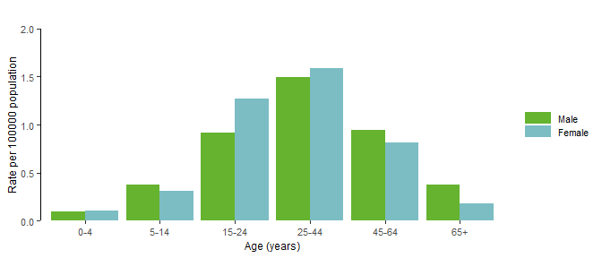

```r
# --- Salmonellosis 2016 bar graph
EpiReport::getAgeGender()
```

The bar graph can also be drafted using external data, and specifying the disease dataset, the disease code and the year to use as reference in the report.

In the example below, we use Zika 2012-2016 data.

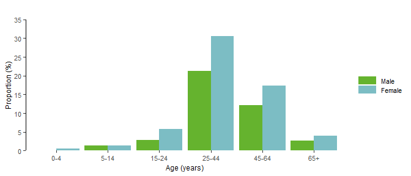

```r
# --- Zika 2016 bar graph
EpiReport::getAgeGender(x = ZIKV2016,
                        disease = "ZIKV",
                        year = 2016)
```

*Figure. Distribution of Zika virus infection proportion (%), by age and gender, EU/EEA, 2016*

[^1]: The European Surveillance System (TESSy) is a system for the collection, analysis and dissemination of data on communicable diseases. EU Member States and EEA countries contribute to the system by uploading their infectious disease surveillance data at regular intervals.
[^2]: 2000/96/EC: Commission Decision of 22 December 1999 on the communicable diseases to be progressively covered by the Community network under Decision No 2119/98/EC of the European Parliament and of the Council. Official Journal, OJ L 28, 03.02.2000, p. 50-53.
[^3]: 2003/534/EC: Commission Decision of 17 July 2003 amending Decision No 2119/98/EC of the European Parliament and of the Council and Decision 2000/96/EC as regards communicable diseases listed in those decisions and amending Decision 2002/253/EC as regards the case definitions for communicable diseases. Official Journal, OJ L 184, 23.07.2003, p. 35-39.
[^4]: 2007/875/EC: Commission Decision of 18 December 2007 amending Decision No 2119/98/EC of the European Parliament and of the Council and Decision 2000/96/EC as regards communicable diseases listed in those decisions. Official Journal, OJ L 344, 28.12.2007, p. 48-49.
[^5]: Commission Decision 2119/98/EC of the Parliament and of the Council of 24 September 1998 setting up a network for the epidemiological surveillance and control of communicable diseases in the Community. Official Journal, OJ L 268, 03/10/1998 p. 1-7.